# Do R&D Expenses Have Any Impact on GDP?

Vitalii Rudko

December, 2020

Abstract

The first objective of this short empirical study is to establish whether there is any relationship between R&D expenses and GDP. The second objective is to conduct a correlation analysis of GDP components. In the first part, I used simple descriptive statistics methods in order to check whether there is any significant correlation between two. In the second part I used correlation analysis to check if there is a connection between the growth of R&D expenses and the components of GDP. In the last part, I conducted Granger causality test, that would help shed a light on usefulness of R&D variable in modelling GDP growth. I used FRED quarterly data for the period of 1990 - 2020.

# 1 Preparation

This section is technical, so it may be skipped.

```r
#Loading data
##Reading csv files
rd <- read.csv2("D:/R_dir/GT/R&D.csv", sep = ",")
gdp <- read.csv2("D:/R_dir/GT/GDP.csv", sep = ",")
gce <- read.csv2("D:/R_dir/GT/GCE.csv", sep = ",")
gpdi <- read.csv2("D:/R_dir/GT/GPDI.csv", sep = ",")
netexp <- read.csv2("D:/R_dir/GT/NETEXP.csv", sep = ",")
pcec <- read.csv2("D:/R_dir/GT/PCEC.csv", sep = ",")

#Merging data
data <- gdp %>%
        right_join(rd) %>%
        right_join(gce) %>%
        right_join(gpdi) %>%
        right_join(netexp) %>%
        right_join(pcec)

names(data) <- c("Date", "GDP", "RD", "GCE", "GDPI", "NETEXP", "PCEC")

##Formatting columns
data[,2:7] <- lapply(data[,2:7], as.numeric)

#Changing sign for NETEXP
data$NETEXP <- -1*data$NETEXP

##Creating dataframe with log returns.
data_log <- logret(data, omit_na = F)

##Changing sign for log returns of NETEXP
data_log$NETEXP <- -1*data_log$NETEXP
data$NETEXP <- -1*data$NETEXP

##Formatting Date column
data$Date <- as.Date(data$Date)
data_log$Date <- as.Date(data_log$Date)

##Subsetting data
data <- data %>% filter(Date >= "1990-01-01")
data_log <- data_log %>% filter(Date >= "1990-01-01")

#Creating time series
whole_ts <- xts(data_log[,3:7], order.by = data_log$Date)
core_ts <- xts(cbind(data_log$RD, data_log$GDPI, data_log$PCEC), order.by =  data_log$Date)
names(core_ts) <- c("RD", "GDPI", "PCEC")
```

# 2 GDP and R&D descriptive analysis

## 2.1 Actual series

Let’s start with plotting the actual series of GDP and R&D for the period of 1990-2020. We observe rising trends in both cases with two shocks in 2008 and 2020.

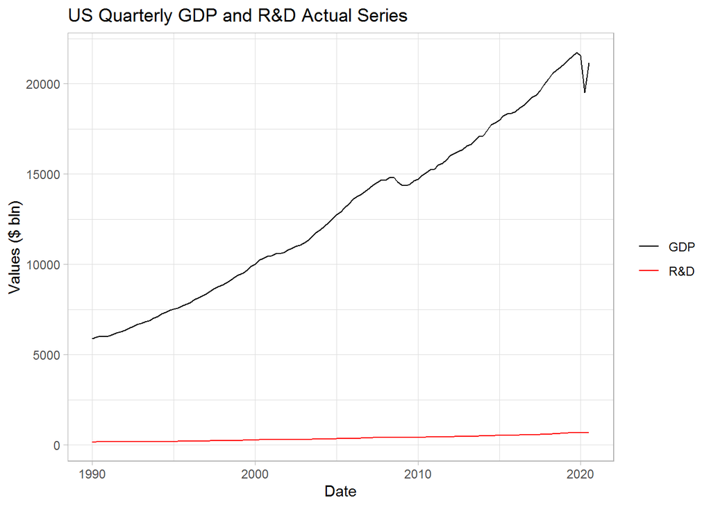

```r
#Plotting real series.
ggplot(data)+
  geom_line(aes(x = Date, y = GDP, col = "GDP"))+
  geom_line(aes(x = Date, y = RD, col = "R&D"))+
   scale_color_manual(name = "",
                     values = c("GDP" = "black",
                                "R&D"  = "red"))+
    labs(y = "Values ($ bln)", title = "US Quarterly GDP and R&D Actual Series")+
  theme_light()
```

Let’s take a closer look at the R&D series. Now It looks more like a GDP series, so there is definitely a correlation between two.

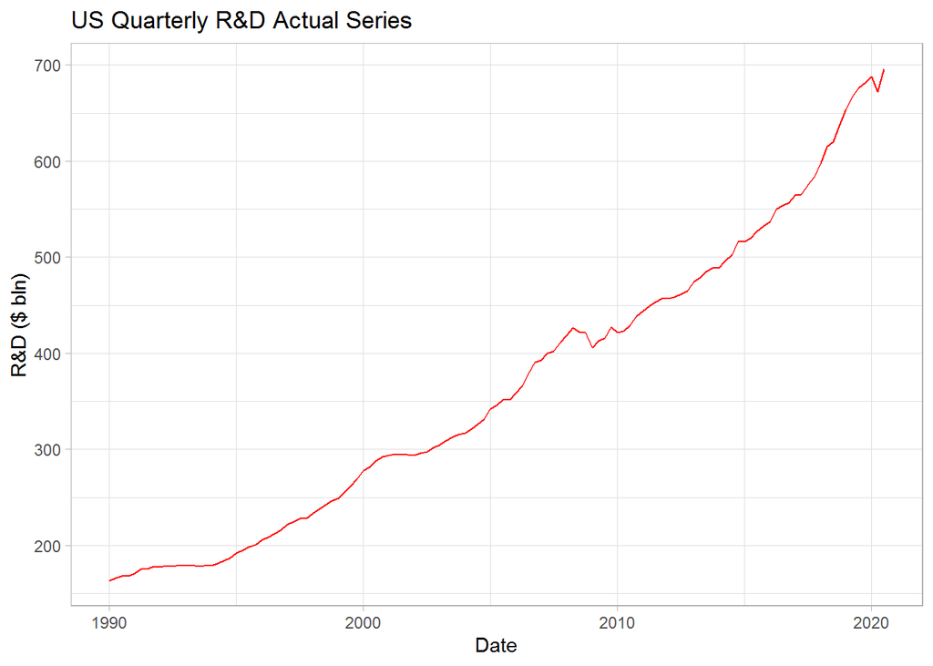

```r
#Plotting real series R&D only.
ggplot(data)+
  geom_line(aes(x = Date, y = RD), col = "red")+
    labs(y = "R&D ($ bln)",
         title = "US Quarterly R&D Actual Series")+
  theme_light()
```

Correlation test shows a strong statistically significant correlation between variables. Although correlation seems to be strong and significant there remains a good chance that it is spurious. Therefore we should take a first order log-difference in order to remove trends in our series.

```r
#Testing correlation.
cor.test(data$GDP, data$RD)
```

```
##
##  Pearson's product-moment correlation
##
## data:  data$GDP and data$RD
## t = 96.848, df = 121, p-value < 2.2e-16
## alternative hypothesis: true correlation is not equal to 0
## 95 percent confidence interval:
##  0.9908754 0.9955289
## sample estimates:
##       cor
## 0.9936115
```

## 2.2 Plotting log series

In this section we are going to remove trends and see what will happen. The plot of calculated growth rates is presented below, so we can notice a somewhat comovement of variables.

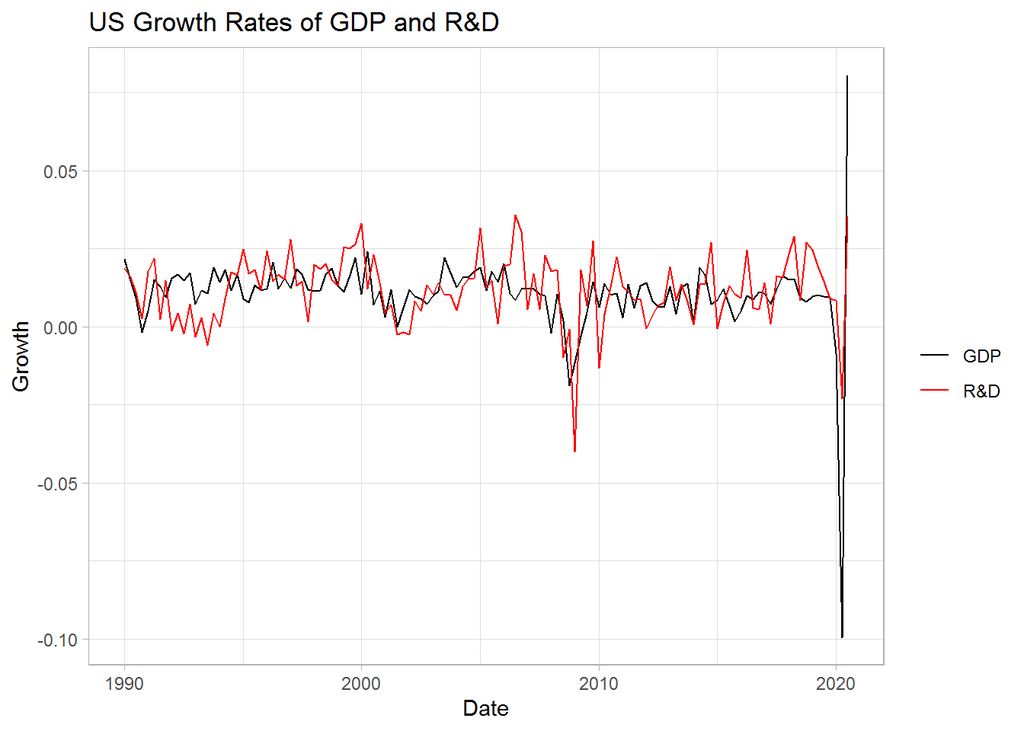

```r
#Plotting lag 1 log differences.
ggplot(data_log)+
  geom_line(aes(x = Date, y = GDP, col = "GDP"))+
  geom_line(aes(x = Date, y = RD, col = "R&D"))+
   scale_color_manual(name = "",
                     labels = c("GDP", "R&D"),
                     values = c("GDP" = "black",
                                "R&D"  = "red"))+
  labs(y = "Growth",
       title = "US Growth Rates of GDP and R&D")+
  theme_light()
```

This time correlation is not as high as previously, but still it is big enough and statically significant. However, that does not tell us much about the relationship between R&D and GDP. So, the further analysis is required.

```r
#Testing correlation.
cor.test(data_log$GDP, data_log$RD)
```

```
##
##  Pearson's product-moment correlation
##
## data:  data_log$GDP and data_log$RD
## t = 5.7043, df = 121, p-value = 8.443e-08
## alternative hypothesis: true correlation is not equal to 0
## 95 percent confidence interval:
##  0.3084615 0.5893588
## sample estimates:
##       cor
## 0.4603565
```

# 3 The GDP Component Descriptive Analysis

## 3.1 Plotting actual series

In this section I am going to decompose GDP into four basic components, namely: consumption, investments, government expenditures and net export. I used PCEC, GDPI, GSE and NETEXP data as a proxy for those variables. More details you can find in the appendix. It is better to plot every series separately in order to see trends. The plots are presented below. All series have growing trends, except NETEXP, which indicates actually the additional demand for capital. Apparently, the series are correlated, but it is not important to check those correlations, since they can be spurious, so I skip this part.

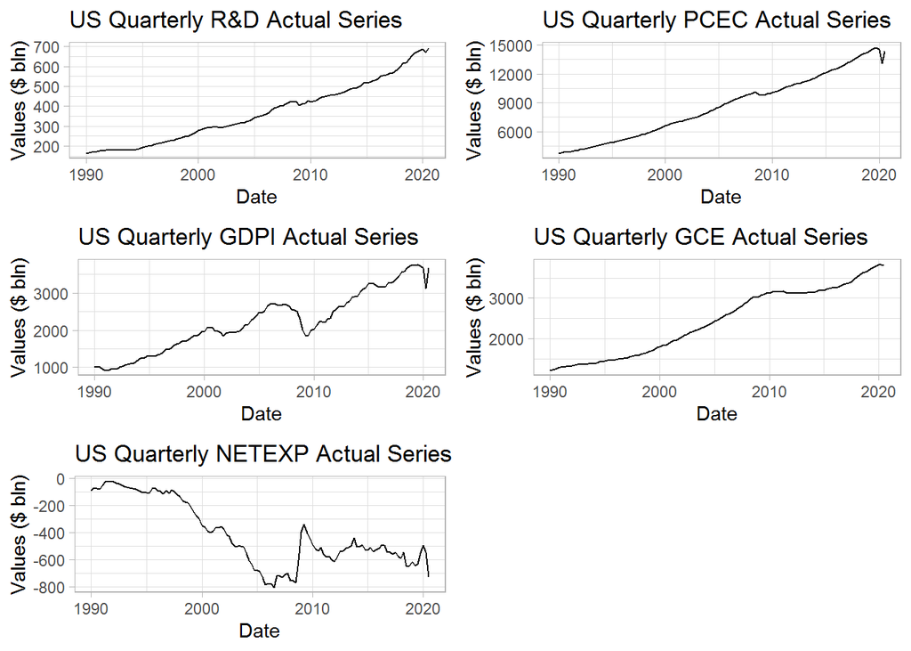

```r
#Plotting real series.
plot_1 <- ggplot(data)+
           geom_line(aes(x = Date, y = RD))+
    labs(y = "Values ($ bln)", title = "US Quarterly R&D Actual Series")+
  theme_light()

plot_2 <- ggplot(data)+
           geom_line(aes(x = Date, y = PCEC))+
    labs(y = "Values ($ bln)", title = "US Quarterly PCEC Actual Series")+
  theme_light()

plot_3 <- ggplot(data)+
           geom_line(aes(x = Date, y = GDPI))+
    labs(y = "Values ($ bln)", title = "US Quarterly GDPI Actual Series")+
  theme_light()

plot_4 <- ggplot(data)+
           geom_line(aes(x = Date, y = GCE))+
    labs(y = "Values ($ bln)", title = "US Quarterly GCE Actual Series")+
  theme_light()

plot_5 <- ggplot(data)+
           geom_line(aes(x = Date, y = NETEXP))+
    labs(y = "Values ($ bln)", title = "US Quarterly NETEXP Actual Series")+
  theme_light()

grid.arrange(plot_1,
             plot_2,
             plot_3,
             plot_4,
             plot_5,
             ncol = 2)
```

## 3.2 Plotting log series

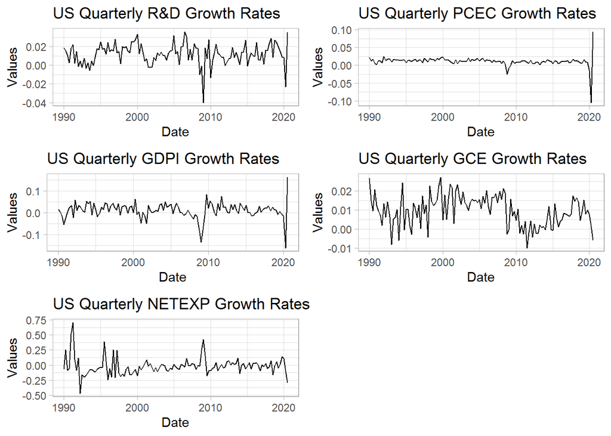

```r
#Plotting real series.
plot_6 <- ggplot(data_log)+
           geom_line(aes(x = Date, y = RD))+
           labs(y = "Values", title = "US Quarterly R&D Growth Rates")+
           theme_light()

plot_7 <- ggplot(data_log)+
           geom_line(aes(x = Date, y = PCEC))+
           labs(y = "Values", title = "US Quarterly PCEC Growth Rates")+
           theme_light()

plot_8 <- ggplot(data_log)+
           geom_line(aes(x = Date, y = GDPI))+
           labs(y = "Values", title = "US Quarterly GDPI Growth Rates")+
           theme_light()

plot_9 <- ggplot(data_log)+
           geom_line(aes(x = Date, y = GCE))+
           labs(y = "Values", title = "US Quarterly GCE Growth Rates")+
           theme_light()

plot_10 <- ggplot(data_log)+
           geom_line(aes(x = Date, y = NETEXP))+
           labs(y = "Values", title = "US Quarterly NETEXP Growth Rates")+
           theme_light()

grid.arrange(plot_6,
             plot_7,
             plot_8,
             plot_9,
             plot_10,
             ncol = 2)
```

## 3.3 Current Correlation Analysis

Below is presented a lower triangle of the cross correlation matrix of the variables. The statistically insignificant values are crossed. We can drop GCE and NETEXP variables, since R&D is not correlated with them. The correlations themselves are discussed in details in the ‘Conclusions’ section.

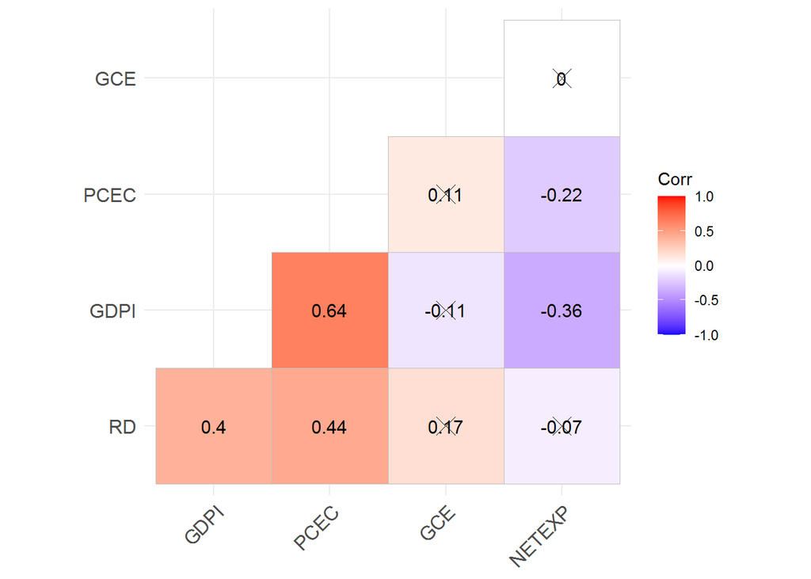

```r
#Calculating correlation matrix
core_corr <-cor(whole_ts)
core_corr_p <- cor_pmat(whole_ts)

##Plotting correlation matrix
ggcorrplot(core_corr,
           hc.order = TRUE,
           lab = T,
           type = "lower",
           p.mat = core_corr_p)
```

## ADF test As we see the chosen variables are stationary with 5% confidence, and in case of PCEC with 10% confidence.

```r
#Adf test of series
adf.test(data_log$RD)
```

```
##
##  Augmented Dickey-Fuller Test
##
## data:  data_log$RD
## Dickey-Fuller = -3.5618, Lag order = 4, p-value = 0.03965
## alternative hypothesis: stationary
```

```r
adf.test(data_log$GDPI)
```

```
##
##  Augmented Dickey-Fuller Test
##
## data:  data_log$GDPI
## Dickey-Fuller = -4.5699, Lag order = 4, p-value = 0.01
## alternative hypothesis: stationary
```

```r
adf.test(data_log$PCEC)
```

```
##
##  Augmented Dickey-Fuller Test
##
## data:  data_log$PCEC
## Dickey-Fuller = -3.3194, Lag order = 4, p-value = 0.07127
## alternative hypothesis: stationary
```

## 3.4 Lagged cross correlation analysis

It is useful to look at the lagged CCF of a variable, just to see whether there is a correlation in a lagged term. As we see, there are significant feedback relations between R&D and GDP. There is also a unidirectional relationship between R&D and PCEC. PCEC and GDPI although seem to have no linear relationship.

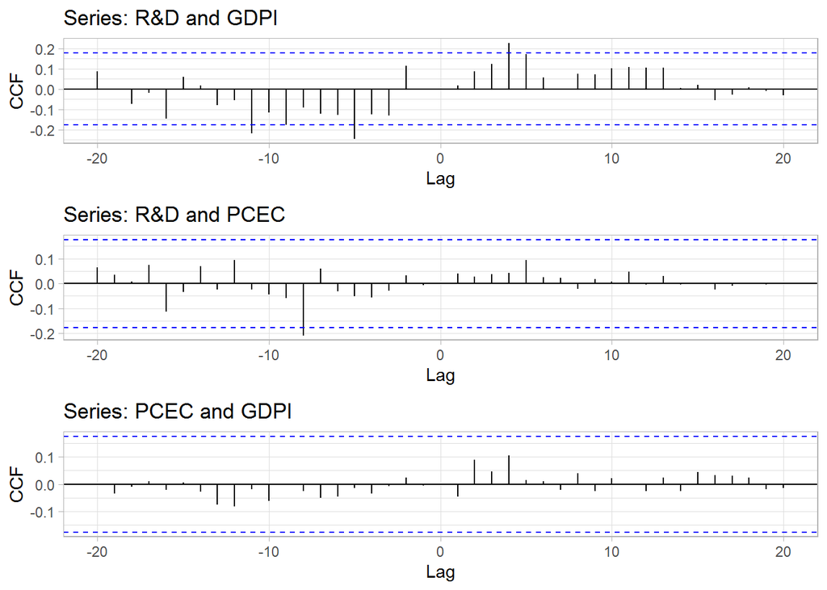

```r
#Plotting CCFs
plot1 <- ggCcf(data_log$RD, data_log$GDPI) +
         labs(title = "Series: R&D and GDPI")+
         theme_light()
plot2 <- ggCcf(data_log$RD, data_log$PCEC)+
         labs(title = "Series: R&D and PCEC")+
         theme_light()
plot3 <- ggCcf(data_log$PCEC, data_log$GDPI)+
         labs(title = "Series: PCEC and GDPI")+
         theme_light()

grid.arrange(plot1,
             plot2,
             plot3,
             ncol = 1)
```

The report from multivariate Ljung box test shows the presence of lagged cross correlations in the variables.

```r
# Multivariate Ljung-Box test
mq(core_ts)
```

```
## Ljung-Box Statistics:
##         m       Q(m)     df    p-value
##  [1,]   1.0      20.5     9.0     0.02
##  [2,]   2.0      40.8    18.0     0.00
##  [3,]   3.0      47.9    27.0     0.01
##  [4,]   4.0      63.1    36.0     0.00
##  [5,]   5.0      81.4    45.0     0.00
##  [6,]   6.0      91.4    54.0     0.00
##  [7,]   7.0     100.4    63.0     0.00
##  [8,]   8.0     111.4    72.0     0.00
##  [9,]   9.0     125.6    81.0     0.00
## [10,]  10.0     134.5    90.0     0.00
## [11,]  11.0     151.5    99.0     0.00
## [12,]  12.0     164.0   108.0     0.00
## [13,]  13.0     169.6   117.0     0.00
## [14,]  14.0     176.0   126.0     0.00
## [15,]  15.0     180.9   135.0     0.01
## [16,]  16.0     189.5   144.0     0.01
## [17,]  17.0     194.8   153.0     0.01
## [18,]  18.0     198.8   162.0     0.03
## [19,]  19.0     199.7   171.0     0.07
## [20,]  20.0     202.7   180.0     0.12
## [21,]  21.0     215.4   189.0     0.09
## [22,]  22.0     224.8   198.0     0.09
## [23,]  23.0     232.8   207.0     0.11
## [24,]  24.0     235.7   216.0     0.17
```

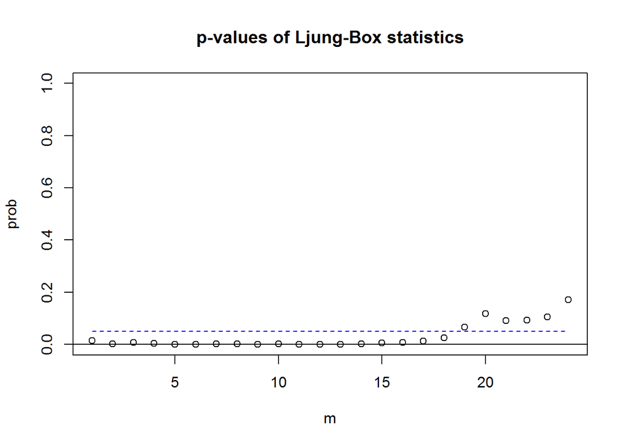

# 4 VAR Model

## 4.1 VAR building

```r
#Building a model
model <- restrict(vars::VAR(core_ts, p = 3, type = "const"))
summary(model)
```

```
##
## VAR Estimation Results:
## =========================
## Endogenous variables: RD, GDPI, PCEC
## Deterministic variables: const
## Sample size: 120
## Log Likelihood: 999.024
## Roots of the characteristic polynomial:
## 0.6479 0.6479 0.5904 0.5904 0.2663     0     0     0     0
## Call:
## vars::VAR(y = core_ts, p = 3, type = "const")
##
##
## Estimation results for equation RD:
## ===================================
## RD = RD.l2 + const
##
##       Estimate Std. Error t value Pr(>|t|)
## RD.l2 0.348517   0.092594   3.764 0.000262 ***
## const 0.007679   0.001473   5.215 7.95e-07 ***
## ---
## Signif. codes:  0 '***' 0.001 '**' 0.01 '*' 0.05 '.' 0.1 ' ' 1
##
##
## Residual standard error: 0.01062 on 118 degrees of freedom
## Multiple R-Squared: 0.581,   Adjusted R-squared: 0.5739
## F-statistic:  81.8 on 2 and 118 DF,  p-value: < 2.2e-16
##
##
## Estimation results for equation GDPI:
## =====================================
## GDPI = GDPI.l2 + PCEC.l3 + const
##
##          Estimate Std. Error t value Pr(>|t|)
## GDPI.l2  0.419743   0.134013   3.132  0.00219 **
## PCEC.l3 -1.350497   0.662219  -2.039  0.04367 *
## const    0.022048   0.007666   2.876  0.00479 **
## ---
## Signif. codes:  0 '***' 0.001 '**' 0.01 '*' 0.05 '.' 0.1 ' ' 1
##
```

[output cut: 19 more lines]

```
## F-statistic: 38.87 on 2 and 118 DF,  p-value: 1.074e-13
##
##
##
## Covariance matrix of residuals:
##             RD      GDPI      PCEC
## RD   1.210e-04 0.0001533 7.471e-05
## GDPI 1.533e-04 0.0013319 3.578e-04
## PCEC 7.471e-05 0.0003578 2.181e-04
##
## Correlation matrix of residuals:
##          RD   GDPI   PCEC
## RD   1.0000 0.3818 0.4598
## GDPI 0.3818 1.0000 0.6637
## PCEC 0.4598 0.6637 1.0000
```

Generally speaking the fit is not the best one. We should take a look at residuals also.

```r
#Extracting fitted values
model.fitted <- fitted(model)
data_log$RD_fitted <- c(rep(NA,3), as.vector(model.fitted[,1]))
data_log$GDPI_fitted <- c(rep(NA,3), as.vector(model.fitted[,2]))
data_log$PCEC_fitted <- c(rep(NA,3), as.vector(model.fitted[,3]))
```

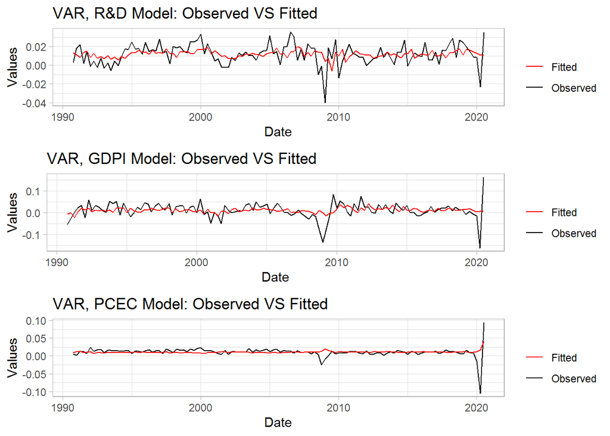

```r
#Plotting fitted values
plot8 <- ggplot(na.omit(data_log))+
          geom_line(aes(x = Date, y = RD, col = "Observed"))+
          geom_line(aes(x = Date, y = RD_fitted, col = "Fitted"))+
          scale_color_manual(name = "",
                             values = c("Observed" = "black",
                                        "Fitted"  = "red"))+
          labs(y = "Values",
               title = "VAR, R&D Model: Observed VS Fitted")+
          theme_light()

plot9 <- ggplot(na.omit(data_log))+
          geom_line(aes(x = Date, y = GDPI, col = "Observed"))+
          geom_line(aes(x = Date, y = GDPI_fitted, col = "Fitted"))+
          scale_color_manual(name = "",
                             values = c("Observed" = "black",
                                        "Fitted"  = "red"))+
          labs(y = "Values",
               title = "VAR, GDPI Model: Observed VS Fitted")+
          theme_light()

plot10 <- ggplot(na.omit(data_log))+
          geom_line(aes(x = Date, y = PCEC, col = "Observed"))+
          geom_line(aes(x = Date, y = PCEC_fitted, col = "Fitted"))+
          scale_color_manual(name = "",
                             values = c("Observed" = "black",
                                        "Fitted"  = "red"))+
          labs(y = "Values",
               title = "VAR, PCEC Model: Observed VS Fitted")+
          theme_light()

grid.arrange(plot8,
             plot9,
             plot10,
             ncol = 1)
```

## 4.2 Residuals

It is important to check autocorrelation in residuals, they must be uncorrelated, and if fact they are not. The test accepted H0. Thus the model captures all of the relations.

```r
#Testing serial correlation of residuals
model.serial <- serial.test(model, type = "PT.asymptotic")
model.serial
```

```
##
##  Portmanteau Test (asymptotic)
##
## data:  Residuals of VAR object model
## Chi-squared = 131.93, df = 117, p-value = 0.1634
```

The plots do not show correlations, which is good, but unfortunately one of the model’s assumptions is violated. The residuals are not normally distributed, so the model is nevertheless biased.

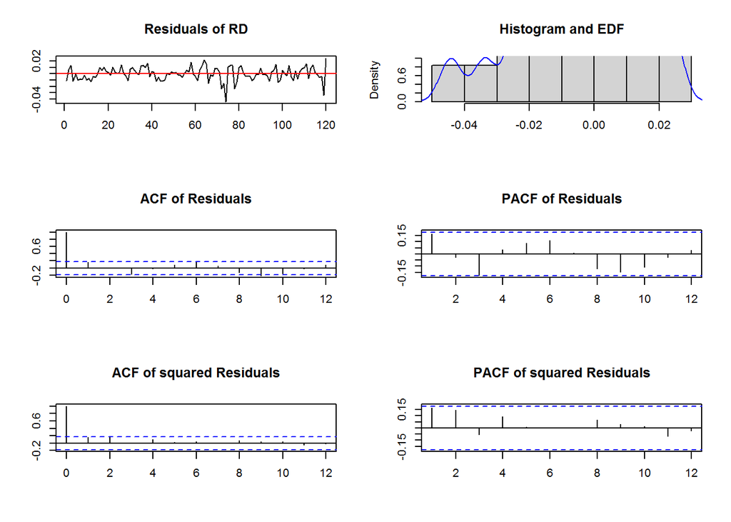

```r
#Residuals graphical analysis R&D
plot(model.serial, names = "RD")
```

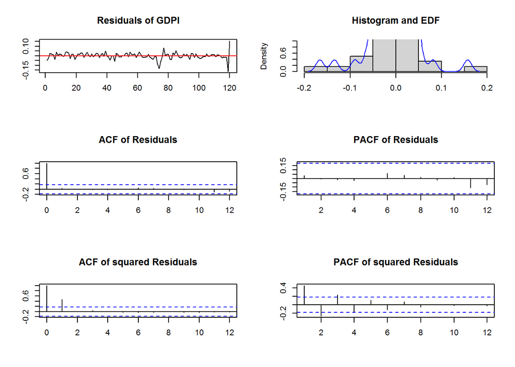

```r
#Residuals graphical analysis R&D
plot(model.serial, names = "GDPI")
```

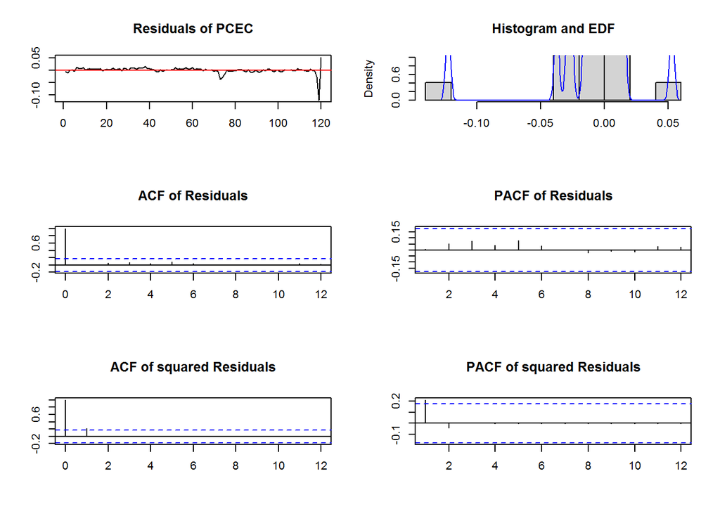

```r
#Residuals graphical analysis R&D
plot(model.serial, names = "PCEC")
```

Normality test confirms violation of the normality assumption.

```r
#Normality test
model.norm.test <- normality.test(model, multivariate.only = TRUE)
model.norm.test
```

```
## $JB
##
##  JB-Test (multivariate)
##
## data:  Residuals of VAR object model
## Chi-squared = 2517.7, df = 6, p-value < 2.2e-16
##
##
## $Skewness
##
##  Skewness only (multivariate)
##
## data:  Residuals of VAR object model
## Chi-squared = 205.62, df = 3, p-value < 2.2e-16
##
##
## $Kurtosis
##
##  Kurtosis only (multivariate)
##
## data:  Residuals of VAR object model
## Chi-squared = 2312.1, df = 3, p-value < 2.2e-16
```

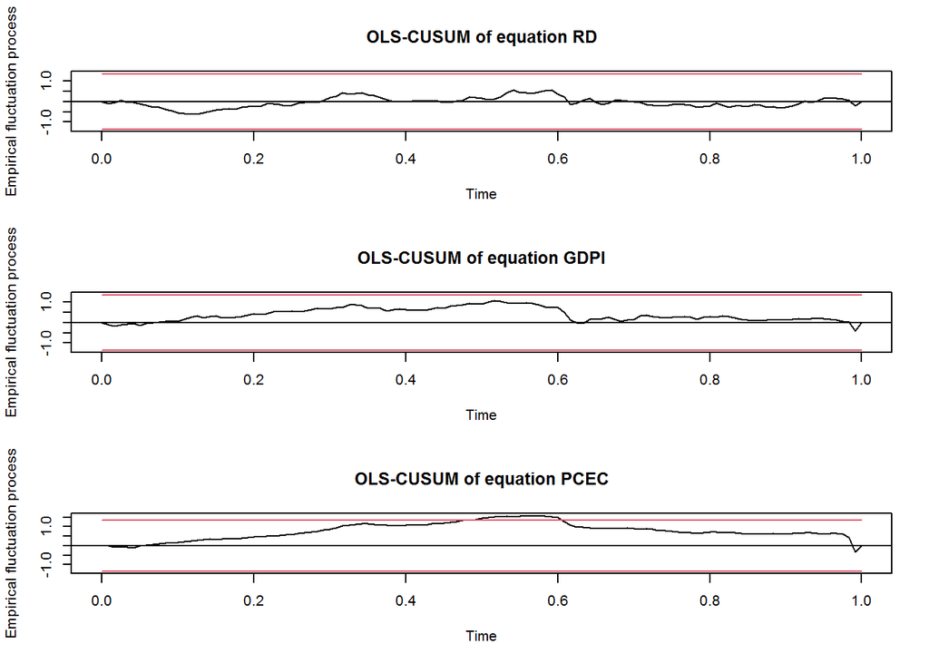

```r
#CUSUM test, graphical analysis.
model.cusum <- stability(model, type = "OLS-CUSUM")
plot(model.cusum)
```

## 4.3 Granger causality test

Finally we can conduct a Granger causality test, which, in short, shows no predictive value of the R&D variable in terms of GDPI and PCEC models, and vice versa.

```r
#Granger causality test for R&D
model.cause1 <- causality(model, cause = "RD")
model.cause1
```

```
## $Granger
##
##  Granger causality H0: RD do not Granger-cause GDPI PCEC
##
## data:  VAR object model
## F-Test = 1.3591, df1 = 6, df2 = 330, p-value = 0.2306
##
##
## $Instant
##
##  H0: No instantaneous causality between: RD and GDPI PCEC
##
## data:  VAR object model
## Chi-squared = 21.795, df = 2, p-value = 1.85e-05
```

```r
#Granger causality test for GDPI and PCEC
model.cause2 <- causality(model, cause = c("GDPI", "PCEC"))
model.cause2
```

```
## $Granger
##
##  Granger causality H0: GDPI PCEC do not Granger-cause RD
##
## data:  VAR object model
## F-Test = 0.94306, df1 = 6, df2 = 330, p-value = 0.4642
##
##
## $Instant
##
##  H0: No instantaneous causality between: GDPI PCEC and RD
##
## data:  VAR object model
## Chi-squared = 21.795, df = 2, p-value = 1.85e-05
```

# 5 Conclusions

The correlation analysis revealed some interesting facts. Specifically, the government expenditures are not significantly correlated with anything. Therefore the macroeconomic situation does not influence GCE, at least in the short term, so it is independent. Another interesting finding is that, there is a higher negative correlation between GDPI and NETEXP, than between PCEC and NETEXP. It has a negative influence on GDP growth in the short term, since when domestic investment is high, the NETEXP is low, therefore the import is high as well. Also, that shows that the US economy depends on its own foreign investments. Other relations are rather obvious.

# 6 Appendix

```r
#Description of the data
#Units:  Billions of Dollars, Seasonally Adjusted Annual Rate
#Frequency:  Quarterly
#Source: FRED
#Links:
#GDP - https://fred.stlouisfed.org/series/GDP
#R&D - https://fred.stlouisfed.org/series/Y694RC1Q027SBEA
#PCEC (Personal Consumption Expenditures) - https://fred.stlouisfed.org/series/PCEC
#GCE (Government Consumption Expenditures and Gross Investment) - https://fred.stlouisfed.org/series/GCE
#GPDI (Gross Private Domestic Investment) - https://fred.stlouisfed.org/series/GPDI
#NETEXP (Net Export) - https://fred.stlouisfed.org/series/NETEXP
```